# A novel sequence alignment algorithm based on deep learning of the protein folding code

10/17/2020

## Introduction

### Main objective

> The key idea is to implicitly learn the protein folding code from many thousands of structural alignments using experimentally determined protein structures.

## Introduction

- 3D structures of proteins are much more conserved than their sequence
- Goal of SAdLSA is to reproduce protein structural alignments when only the sequences are known
- SAdLSA does not require any structural information as input

## Methods

- Convolutional Neural Network (ResNet architecture)
- sequence profiles generated from the classic sequence search algorithms as input
- learning the residue-residue distances obtained by optimal structural superposition on the two structures encoded by their respective sequences
- the learning focuses on cross-sequence residue distances between pairs of proteins displayed in the structural alignment.

## Deep learning model architecture

- Input: two sequence profiles from PSI-BLAST or HH-suite (\(N_k \times 20\))
- Outer product of these profiles
- Objective of network is to predict matrix of alignment distances
- Setup: 80 conv layers + softmax (64 filters size 3x3 or 5x5)
- outputs are transposed and averaged to last layer which outputs 22 categories
- Each category represents distance from 1A to 21A (extra category for ignored pairs)

## Flowchart of SAdLSA

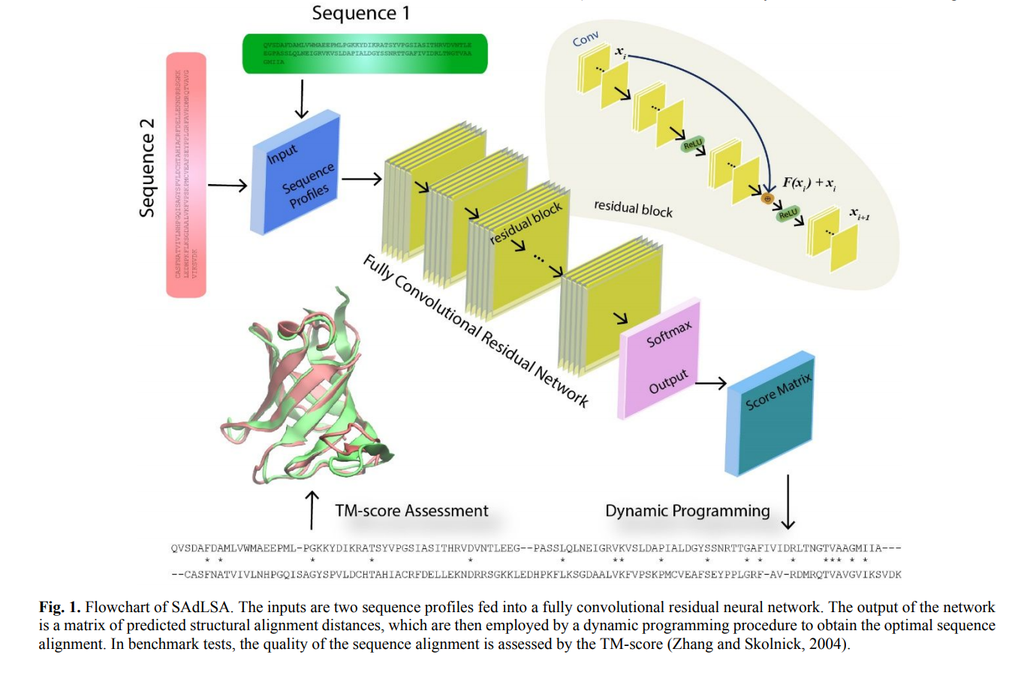

## DL model output

- probability matrix converted into a mean distance matrix
- distance matrix is used to obtain the optimal alignment (Smith-Waterman algorithm)

## Datasets

- training distance labels are created from structural alignments by APoc (improved version of TM-align)

### Pure \(\alpha\) and \(\beta\) data sets

- 695 training \(\alpha\)-helical and 121 testing \(\beta\)-sheet structures
- template structure library: 5884 domains

## Datasets continued

### SCOP10 testing data sets

- 3k domain cluster representatives
- PAIR947 for assessing pairwise alignment quality given the sequence pairs
- LIB593 for searching a sequence library to find the sequences with the closest matching pairs of structure

### SCOP30 training/validation data sets

- 5884 SCOP domain representatives
- removed homologs and SCOP10 domain test set
- APoc structure alignment with TM-score > 0.4
- 79k pairs into 5 train/val sets

## Sequence profiling

- PSI-BLAST used to derive sequence profile from UniProt Ref90 database.
- HH-suite used to derive sequence profile from Uniclust30 database.
- HMM model approach gives best TM-score

## Alignment assessment

What is a TM-score?

- assesses quality of sequence alignment
- ranging from 0 to 1
- protein length-indepedent
- TM-score > 0.4 indicates statistically significant alignment

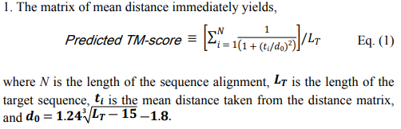

## Results

## Aligning sequence encoding \(\beta\)-structures from learning sequences encoding \(\alpha\)-structures

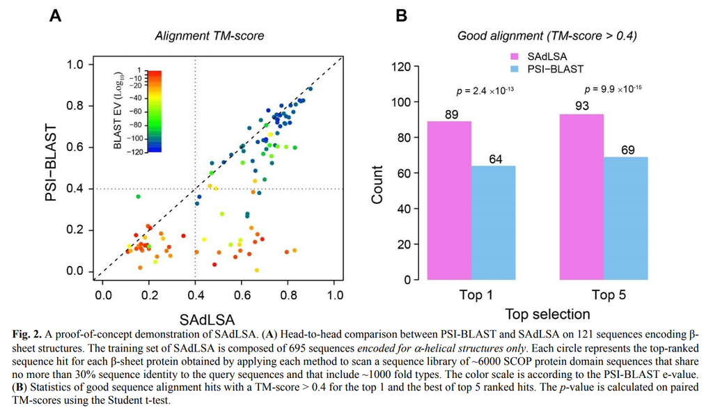

## Pairwise sequence alignment

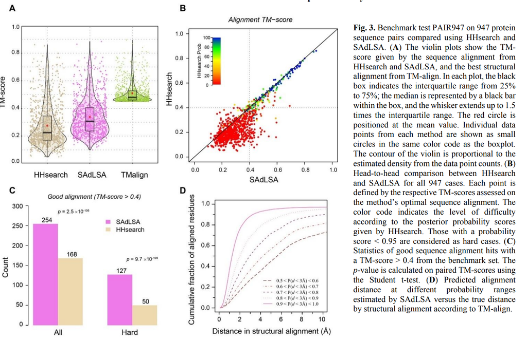

## Sequence library search test

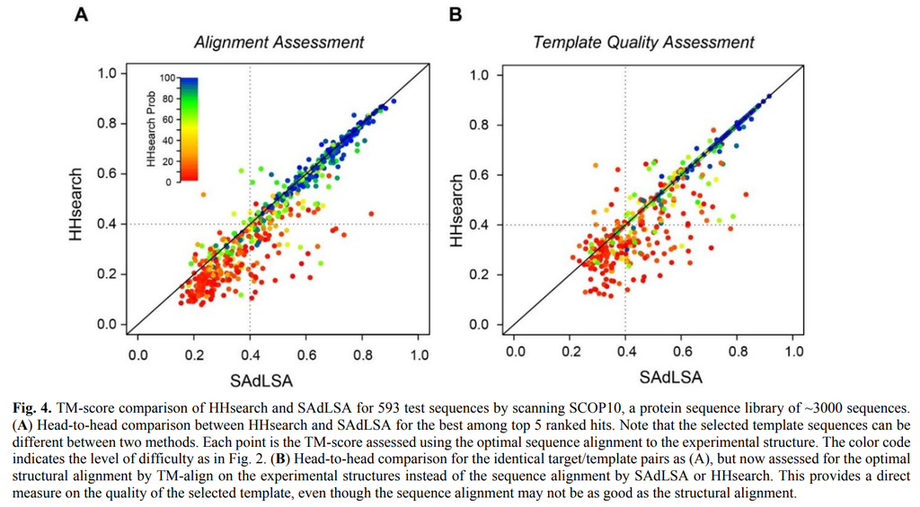

## Summmary

- Sequence alignment is essentially a comparison of the folding code encrypted within protein sequences
- substitution tables (i.e. BLOSUM) can be viewed as a mean-field approximation, HMMs also considers immediate neighboring residue.
- SAdLSA can detect non-local, long-range effects arising from correlations between residues that are distant in the sequence